# Homework 1

Seth Harrison

A)Install the astsa package in R Studio. Plot the jj data described in Example 1.1 then answer the following questions:

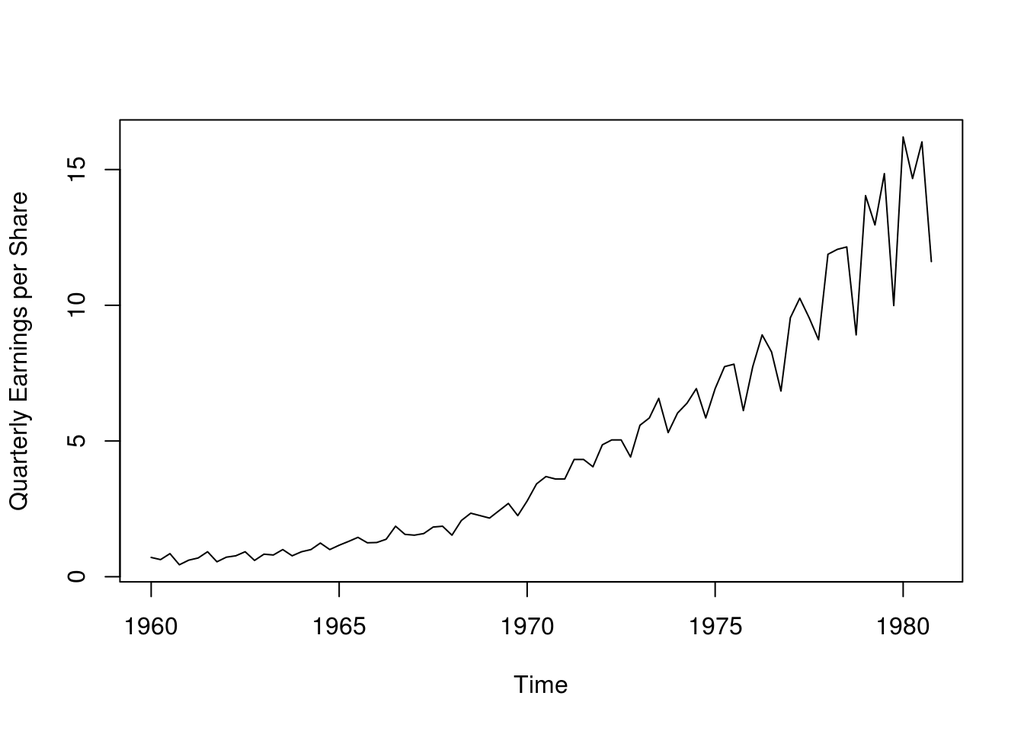

```r
library(astsa) # SEE THE FOOTNOTE
plotEQS <- plot(jj, type="l", ylab="Quarterly Earnings per Share")
```

```r
plotEQS
```

1. Is the time series stationary? Explain.

```r
var(jj)
```

```
## [1] 18.57602
```

The time series is not stationary because the variance increases as time passes and the collection of values is not identical to the time shifted values.

2. The variance is clearly not constant, it generally increases with time. Do a log transformation of the data. Does the log-transformed data have a more constant variance?

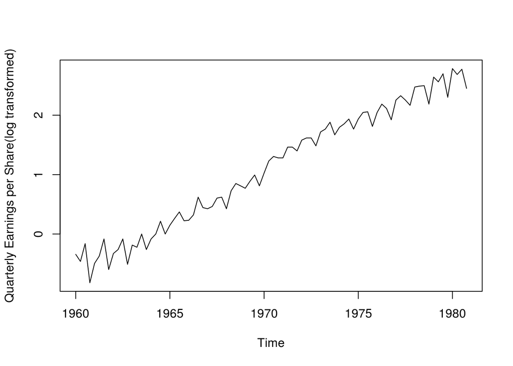

```r
plotLogEQS <- plot(log(jj), type="l", ylab="Quarterly Earnings per Share(log transformed)")
```

```r
plotLogEQS
```

```r
var(log(jj))
```

```
## [1] 1.059431
```

It appears that the variance remains somewhat constant when the data is log transformed.

3. Do a lag 1 differencing of the log-transformed data. Is this data more stationary than the original data?

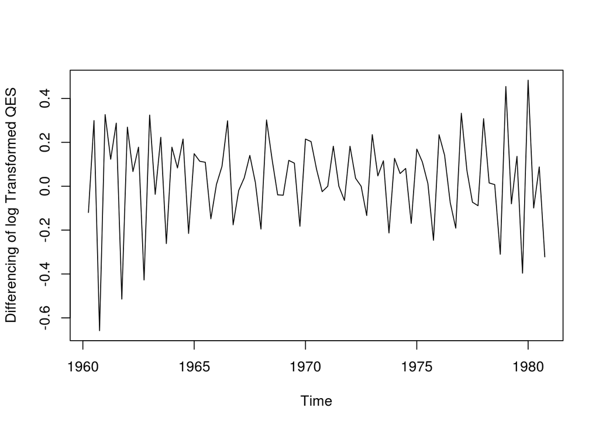

```r
plotDiffLogEQS <- plot(diff(log(jj), lag = 1), type="l", ylab="Differencing of log Transformed QES")
```

```r
plotDiffLogEQS
```

```r
var(diff(log(jj), lag = 1))
```

```
## [1] 0.04418932
```

The variance is .0442, which is significantly lower than the original data.

4. Fit a simple linear regression model to the original time series data. Obtain and interpret the slope of the regression line in context of the data.

```r
lm(jj ~ c(1:length(jj)))
```

```
##
## Call:
## lm(formula = jj ~ c(1:length(jj)))
##
## Coefficients:
##     (Intercept)  c(1:length(jj))
##          -2.130            0.163
```

With a slope of 0.163, we would expect an increase of of 0.163 in earnings each quarter, assuming the linear regression model was a good interpretation for the data.

5. Obtain the residuals after fitting the regression model in #4. Plot the residuals. Do the residuals look stationary?

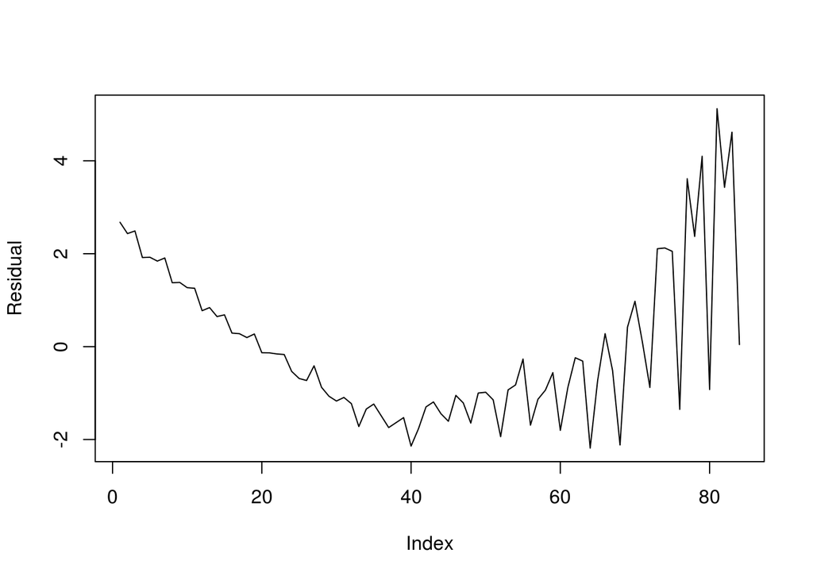

```r
lineMod <- lm(jj ~ c(1:length(jj)))
plot(resid(lineMod), type = "l", ylab = "Residual")
```

```r
var(resid(lineMod))
```

```
## [1] 2.7581
```

Based on the increasing variance of the residuals, I would say they are not stable.

B)Do excercise 1.2 from the textbook.

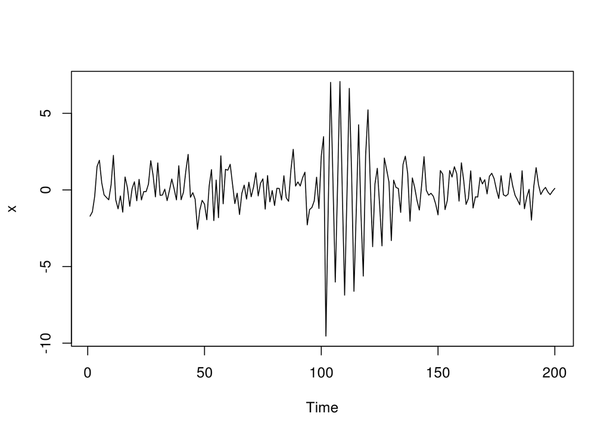

```r
s = c(rep(0,100), 10*exp(-(1:100)/20)*cos(2*pi*1:100/4))
x = s + rnorm(200)
plot.ts(x)
```

(b)

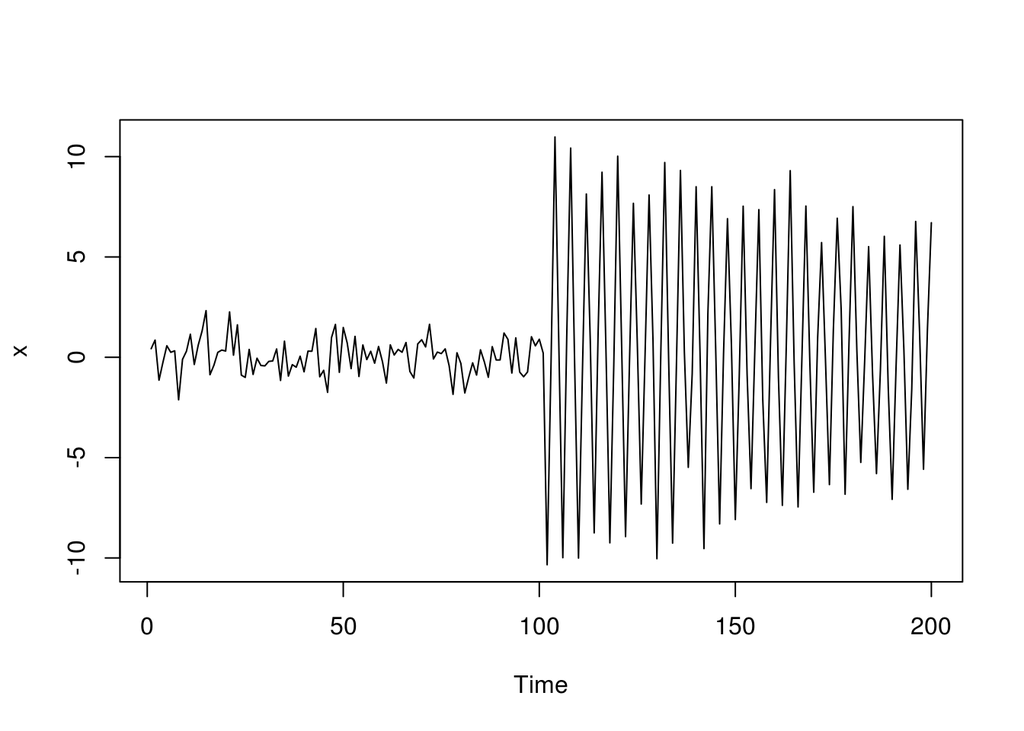

```r
s = c(rep(0,100), 10*exp(-(1:100)/200)*cos(2*pi*1:100/4))
x = s + rnorm(200)
plot.ts(x)
```

(c)Compare the general appearance of the series (a) and (b) with the earthquake series and the explosion series shown in Figure 1.7. In addition, plot (or sketch) and compare the signal modulators (a) exp{−t/20} and (b) exp{−t/200}, for t = 1, 2, . . ., 100.

Figure A shares a similar trend with the explosion series, showing small variance until one large spike in variance followed by decreasing variance. Figure B is similar to the earthquake series where the variance is constant and relatively small until there is a large spike in variance which doesn’t appear to immediately begin decreasing.

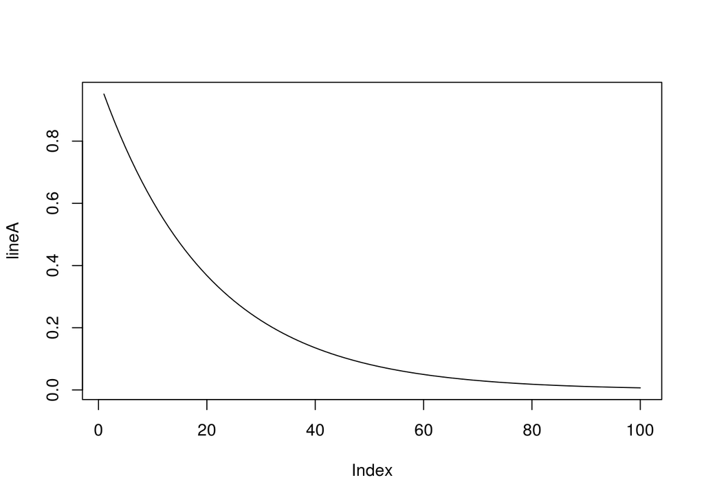

```r
lineA <- exp(-(1:100)/20)
lineB <- exp(-(1:100)/200)
plot(lineA, type = "l")
```

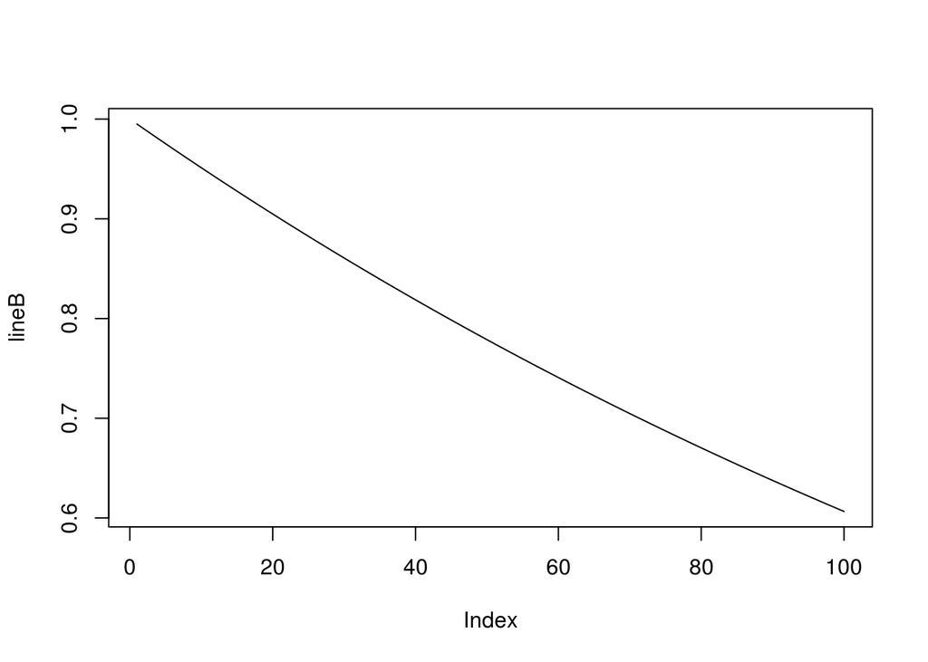

```r
plot(lineB, type = "l")
```

The time series for part A decays much faster than the time series from part B.